# Lecture 11 - Boosting

Joseph Haymaker

11/13/2017

# Boosting

- Text book 8.2.3

## Boosting

- Boosting with the squared error loss
- Forward stagewise

### 1) Boosting

### 2) Comparison with RF

#### Use Hitters dataset

- Goal is to do prediction

```r
library(ISLR)
help(Hitters)
data.comp <- na.omit(Hitters)  # For simplicity
dim(data.comp)            # We are keeping 263 players
```

```
## [1] 263  20
```

```r
data.comp$LogSalary <- log(data.comp$Salary)  # add LogSalary
names(data.comp)
```

```
##  [1] "AtBat"     "Hits"      "HmRun"     "Runs"      "RBI"
##  [6] "Walks"     "Years"     "CAtBat"    "CHits"     "CHmRun"
## [11] "CRuns"     "CRBI"      "CWalks"    "League"    "Division"
## [16] "PutOuts"   "Assists"   "Errors"    "Salary"    "NewLeague"
## [21] "LogSalary"
```

```r
data1 <- data.comp[,-19]

library(gbm) # boosting machine

data1 <- data1[sample(nrow(data1)), ] # make sure the row number plays no row!
```

## 1) Boosting in action

**i) get familiar with `gbm()`**

```r
ntree <- 200
fit.boost <- gbm(LogSalary ~., data = data1, distribution = "gaussian", n.trees = ntree, interaction.depth = 2,
                 train.fraction = .7)
```

**arguments**:

- `distribution` = “gaussian” for continuous response and “bernoulli”/“multinomial” for two/more two/more classes.
- `interation.depth` = depth of the tree, the number of splits. d=1 (default) is a stump tree, i.e. only one split
- `n.trees` = number of the trees to be updated, default=100
- `train.fraction` = training set, the error will be testing error with the remaining data. **Caution**: the first train.fraction of the data will be used as a training set + Make sure the data is in a random order. Default=1
- `bag.fraction` = fraction of the training data, fraction of the data used for training the next tree + default set at .5
- `shrinkage` = 0.001 set as default.

#### Output

```r
names(fit.boost)
```

```
##  [1] "initF"             "fit"               "train.error"
##  [4] "valid.error"       "oobag.improve"     "trees"
##  [7] "c.splits"          "bag.fraction"      "distribution"
## [10] "interaction.depth" "n.minobsinnode"    "num.classes"
## [13] "n.trees"           "nTrain"            "train.fraction"
## [16] "response.name"     "shrinkage"         "var.levels"
## [19] "var.monotone"      "var.names"         "var.type"
## [22] "verbose"           "data"              "Terms"
## [25] "cv.folds"          "call"              "m"
```

```r
fit.boost$fit # hat y
```

```
##   [1] 5.801712 5.943821 6.111460 6.000267 6.029454 5.776236 5.776236
##   [8] 6.088590 5.781254 6.084009 6.047103 5.821880 5.885520 6.024074
##  [15] 6.084709 6.061352 5.777140 6.021698 6.071222 6.061931 6.068387
##  [22] 6.010329 6.057132 5.798913 6.084474 6.119428 5.776236 6.094279
##  [29] 6.028003 6.104507 6.091712 5.776236 6.083188 6.043089 6.056120
##  [36] 6.091589 6.083825 6.026480 5.795792 6.006751 5.777140 5.777140
##  [43] 5.796402 6.024680 5.776236 6.055566 6.039672 6.105580 6.054686
##  [50] 6.115236 6.097334 6.042832 6.094291 6.119433 6.001661 5.806574
##  [57] 6.012221 6.120114 6.041772 5.921408 5.777140 5.776236 5.830169
##  [64] 6.036624 5.957157 5.776236 5.818366 6.050227 6.068951 6.079723
##  [71] 5.976170 5.777867 6.034950 5.776236 6.001458 6.017618 5.776236
##  [78] 6.108343 6.020573 6.042505 5.786158 6.032987 5.826808 6.055047
##  [85] 6.024025 5.777140 6.112193 5.776236 5.776236 5.780363 6.039570
##  [92] 6.073183 5.821802 6.057068 6.043957 6.094386 5.910519 6.053761
##  [99] 6.022458 6.097921 5.776236 5.797400 6.036678 5.776236 6.113175
```

[output cut: 23 more lines]

```r
fit.boost$train.error # training errors
```

```
##   [1] 0.8519430 0.8508684 0.8498113 0.8488146 0.8477446 0.8467166 0.8456613
##   [8] 0.8446320 0.8436050 0.8425395 0.8413849 0.8403641 0.8391617 0.8381144
##  [15] 0.8370717 0.8359868 0.8349697 0.8339454 0.8328559 0.8316838 0.8305717
##  [22] 0.8294765 0.8284324 0.8274462 0.8264188 0.8252724 0.8242249 0.8231895
##  [29] 0.8221618 0.8210352 0.8198295 0.8188989 0.8178668 0.8167930 0.8158554
##  [36] 0.8147977 0.8138673 0.8128113 0.8117775 0.8107869 0.8097578 0.8087659
##  [43] 0.8077836 0.8067039 0.8057396 0.8047016 0.8036762 0.8026804 0.8017229
##  [50] 0.8006387 0.7995907 0.7987096 0.7977273 0.7967254 0.7957376 0.7947836
##  [57] 0.7937641 0.7928426 0.7918502 0.7909071 0.7898697 0.7889478 0.7880150
##  [64] 0.7870024 0.7860553 0.7850285 0.7842198 0.7833145 0.7823590 0.7814267
##  [71] 0.7805569 0.7795490 0.7785835 0.7775477 0.7766573 0.7756552 0.7747802
##  [78] 0.7738543 0.7728024 0.7717935 0.7708007 0.7698646 0.7689271 0.7680624
##  [85] 0.7671520 0.7662625 0.7652577 0.7643229 0.7634404 0.7624494 0.7614993
##  [92] 0.7605244 0.7596373 0.7587416 0.7579490 0.7570355 0.7560857 0.7551351
##  [99] 0.7542919 0.7534897 0.7526116 0.7516763 0.7507867 0.7498717 0.7489748
## [106] 0.7481200 0.7472341 0.7463590 0.7454176 0.7445363 0.7436927 0.7427681
## [113] 0.7419859 0.7411132 0.7401732 0.7392683 0.7383153 0.7374055 0.7365524
## [120] 0.7356381 0.7347130 0.7338148 0.7330275 0.7321230 0.7313095 0.7304042
## [127] 0.7295737 0.7286238 0.7276969 0.7267533 0.7258750 0.7250664 0.7242359
## [134] 0.7233806 0.7224950 0.7216884 0.7208229 0.7199267 0.7189882 0.7181264
## [141] 0.7172244 0.7163333 0.7154303 0.7145705 0.7137746 0.7129819 0.7121572
## [148] 0.7112910 0.7104585 0.7096149 0.7088402 0.7080103 0.7071615 0.7062824
## [155] 0.7054092 0.7046667 0.7037390 0.7028180 0.7019755 0.7011736 0.7003655
## [162] 0.6994820 0.6987331 0.6979496 0.6971018 0.6963257 0.6954831 0.6946888
## [169] 0.6938924 0.6931080 0.6923858 0.6915504 0.6907362 0.6899407 0.6891859
## [176] 0.6884010 0.6876208 0.6868623 0.6861247 0.6852646 0.6844734 0.6836769
## [183] 0.6828899 0.6819927 0.6812795 0.6804846 0.6796874 0.6789080 0.6781694
## [190] 0.6774443 0.6767170 0.6760154 0.6752468 0.6745530 0.6738412 0.6731697
## [197] 0.6723549 0.6715602 0.6708204 0.6701267
```

```r
fit.boost$valid.error # testing errors if train.fraction is given
```

```
##   [1] 0.6397063 0.6387338 0.6377336 0.6368400 0.6359049 0.6349782 0.6340813
##   [8] 0.6331470 0.6322303 0.6312338 0.6301407 0.6292631 0.6282243 0.6273491
##  [15] 0.6264663 0.6255515 0.6246392 0.6237386 0.6227175 0.6217250 0.6207501
##  [22] 0.6197815 0.6188313 0.6179511 0.6170167 0.6159298 0.6149976 0.6140752
##  [29] 0.6130607 0.6120662 0.6109632 0.6101052 0.6092402 0.6082770 0.6074903
##  [36] 0.6064951 0.6056583 0.6047172 0.6037462 0.6028773 0.6019968 0.6010612
##  [43] 0.6001314 0.5991242 0.5982702 0.5973232 0.5964206 0.5954835 0.5946726
##  [50] 0.5937932 0.5928730 0.5920890 0.5911516 0.5901910 0.5892344 0.5883622
##  [57] 0.5874430 0.5866253 0.5857395 0.5849203 0.5839890 0.5831403 0.5823116
##  [64] 0.5813812 0.5805360 0.5796287 0.5788916 0.5780697 0.5772656 0.5764279
##  [71] 0.5757446 0.5748455 0.5740221 0.5731509 0.5723849 0.5714417 0.5706390
##  [78] 0.5697923 0.5688189 0.5679744 0.5671117 0.5663045 0.5654669 0.5646815
##  [85] 0.5639412 0.5632103 0.5622707 0.5614598 0.5605846 0.5596841 0.5588988
##  [92] 0.5580311 0.5572668 0.5564576 0.5557641 0.5550054 0.5541619 0.5533385
##  [99] 0.5525908 0.5518307 0.5510568 0.5502897 0.5495538 0.5487342 0.5479344
## [106] 0.5471603 0.5463965 0.5456129 0.5447975 0.5439925 0.5432545 0.5424463
## [113] 0.5417592 0.5409899 0.5402244 0.5394416 0.5385319 0.5377535 0.5370029
## [120] 0.5361768 0.5353570 0.5345480 0.5338246 0.5330477 0.5323796 0.5315376
## [127] 0.5308153 0.5300232 0.5291689 0.5282770 0.5275518 0.5268028 0.5260416
## [134] 0.5253109 0.5245427 0.5238574 0.5231047 0.5222878 0.5214808 0.5206961
## [141] 0.5199366 0.5191107 0.5184051 0.5176539 0.5169707 0.5162563 0.5154935
## [148] 0.5147238 0.5139242 0.5131554 0.5124327 0.5116706 0.5109642 0.5101591
## [155] 0.5093916 0.5086929 0.5078424 0.5070943 0.5063143 0.5055372 0.5048005
## [162] 0.5040666 0.5033775 0.5026826 0.5019364 0.5013007 0.5006149 0.4999311
## [169] 0.4992449 0.4986018 0.4979297 0.4972411 0.4965422 0.4958667 0.4952221
## [176] 0.4945661 0.4939002 0.4933275 0.4926887 0.4919382 0.4912926 0.4906312
## [183] 0.4899519 0.4891587 0.4885044 0.4877795 0.4871184 0.4864604 0.4858336
## [190] 0.4852369 0.4846268 0.4840394 0.4833742 0.4827833 0.4821275 0.4815160
## [197] 0.4808315 0.4801039 0.4794847 0.4789125
```

```r
yhat <- predict(fit.boost, newdata = data1, n.trees = ntree) # prediction, in this case it is the same as fit.boost$fit
```

**ii) Tune number of trees needed by minimizing the testing errors**

- Investigate the testing/training errors vs. number of iterations
- We may use `gbm.perf(object, plot.it = TRUE, method="test")`

**Remember that the training data will be the first 80% rows.**

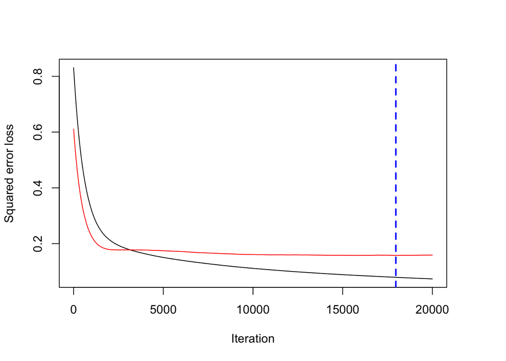

```
## [1] 17964
```

```r
ntree <- 20000
fit.boost <- gbm(LogSalary~., data = data1, distribution = "gaussian", n.trees = ntree, interaction.depth = 2,
                 train.fraction = .8)
gbm.perf(fit.boost, method ="test")
```

Output the optimal number of trees by min the testing errors. + **red**: `fit.boost$valid.error` (testing errors) + **black**: `fit.boost$train.error` (training errors)

Notice the testing errors are smaller than that of training error for many iterations. **(testing error < training error)**

The above plots are same as:

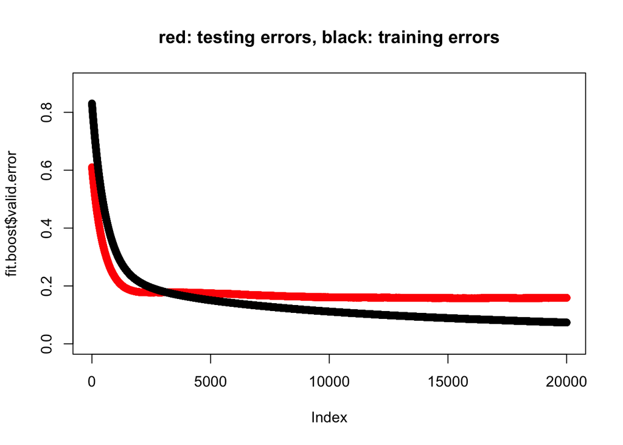

```r
plot(fit.boost$valid.error, col= "red",
     main="red: testing errors, black: training errors",
     ylim = c(0, .9))
points(fit.boost$train.error, col="black")
```

We now use the optimal number of trees as our final prediction function

To match with the `gbm()` **training** and **testing** data, we set

```r
n.t <- floor(.8*263)
data.train <- data1[1:n.t, ]   # n.t <- floor(.8*263)
data.test <- data1[-(1:n.t), ]

B <- gbm.perf(fit.boost, method ="test") # optimal number of trees
yhat <- predict(fit.boost, newdata = data.test, n.trees = gbm.perf(fit.boost, method ="test") )
```

[figure not shown]

```r
fit.boost.test <- mean(yhat-data.test$LogSalary)^2  # the testing error for boosting
```

## 2) Comparison: boosting and RF or any other your favorites

Lastly let’s compare the testing errors between random forest and boosting

```r
fit.rf.testing <- randomForest(LogSalary~., data.train, xtest=data.test[, -20],
                               ytest=data.test[,20], mtry=6, ntree=500)
fit.rf.testing$mse[500]   # testing error
```

```
## [1] 0.2321101
```

```r
fit.rf <-randomForest(LogSalary~., data.train,  mtry=6, ntree=500)
mean((predict(fit.rf, data.test)-data.test[, 20])^2)
```

```
## [1] 0.09833929
```

output the testing errors for boosting and rf

```r
print(c(fit.boost.test,fit.rf.testing$mse[500] )) ### wowwww, who's a winner????
```

```
## [1] 0.0001070798 0.2321101172
```

End of Boosting + Will try to fill in an example of boosting classification

## Boosting for classifications

- Will fill this in
- Gene data Khan
- Will try to fill this in
- Seems to be a magic: 83 obsn with over 2300 gene expressions points

```r
library(ISLR)
gene.train <- data.frame(Khan$xtrain, tumor = Khan$ytrain)
gene.test <- data.frame(Khan$xtest, tumor = Khan$ytest)
gene <- rbind(gene.train, gene.test)
genex <- rbind(data.frame(Khan$xtrain), data.frame(Khan$xtest))
# names(gene)
# head(gene, 10)
```

```r
library(dplyr)
library(data.table)
```

```r
library(ggplot2)
gene <- data.table(gene)
tmp <- gene[, lapply(.SD, mean), by=tumor]
# heatmap(genex)
```

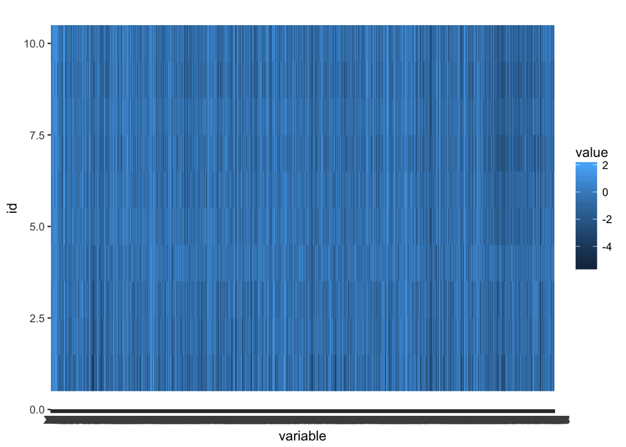

```r
gene.map <- data.frame(id = seq(1:nrow(gene)), genex)
gene.map.melt <- melt(gene.map, id="id")
gene.map.sub <- gene.map[1:10,]
gene.map.sub.melt <- melt(gene.map.sub, id="id")
ggplot(gene.map.sub.melt, aes(x=variable, y=id)) + geom_tile(aes(fill=value))
```

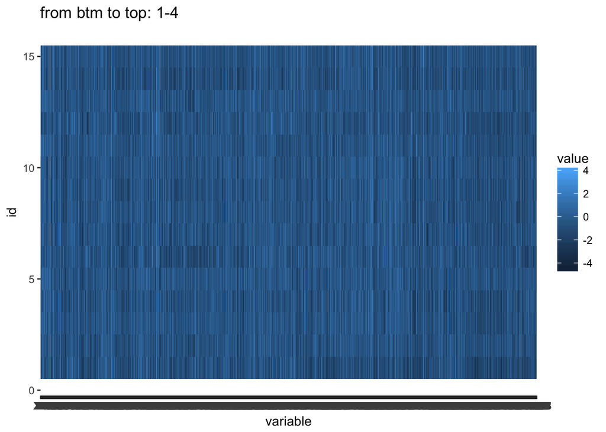

```r
gene.map.sub <- gene[sample(nrow(gene), 15),]
gene.map.sub <- gene.map.sub[order(gene.map.sub$tumor),]
gene.map.sub <- data.frame(id = seq(1:nrow(gene.map.sub)), gene.map.sub)
gene.map.sub.melt <- melt(gene.map.sub, id="id")
ggplot(gene.map.sub.melt, aes(x=variable, y=id)) +
  geom_tile(aes(fill=value)) +
  ggtitle("from btm to top: 1-4")
```

```r
data.frame(gene.map.sub$tumor, gene.map.sub$id)
```

```
##    gene.map.sub.tumor gene.map.sub.id
## 1                   1               1
## 2                   1               2
## 3                   2               3
## 4                   2               4
## 5                   2               5
## 6                   2               6
## 7                   3               7
## 8                   3               8
## 9                   3               9
## 10                  3              10
## 11                  4              11
## 12                  4              12
## 13                  4              13
## 14                  4              14
## 15                  4              15
```